# Time Arrival Estimation with Deep Learning

Ardian the Great

August 19, 2023

## **Introduction**

This project is a continuation of my previous project titled “Time Arrival Estimation with Machine Learning.” In this iteration, I aim to enhance the predictive model developed earlier by leveraging advanced machine learning algorithms and deep learning architectures. This project revolves around analyzing NYC taxi trips and their respective durations. The primary objective is to construct an effective machine learning model capable of predicting trip durations. By achieving accurate predictions of trip durations, we can obtain reliable estimations for the expected arrival times of trips.

Developing an effective machine learning model for time arrival estimation offers several significant business advantages:

> 1. `Better Customer Experience`: Predicting trip durations helps passengers plan better, reducing wait times and travel uncertainty
> 2. `Efficient Dispatch and Routing`: Accurate predictions optimize taxi assignments and routes, reducing idle time and improving fleet use
> 3. `Quality Service`: Reliable estimates reduce rushed driving, leading to safer and more comfortable rides
> 4. `Cost Efficiency`: Optimized operations save fuel, vehicle wear, and overall expenses
> 5. `Competitive Edge`: Reliable predictions attract customers and boost loyalty, setting you apart in the market
> 6. `Smart Decision-Making`: Data analysis unveils peak times, routes, and demand patterns for informed choices
> 7. `Partnerships and Integration`: Accurate predictions open doors for collaborations with other services
> 8. `Effective Marketing`: Promote precise arrival times to attract more users and repeat business
> 9. `Efficient Workforce`: Predictive insights aid in allocating drivers as per demand, reducing downtime
> 10. `Data Value`: Monetize data by selling insights on traffic patterns and commuter behavior.

## **Data Pre-processing**

### Import used libraries

```r
library(dplyr)
library(lubridate)
library(Ardian) # My own package
library(GGally)
library(ggplot2)
library(caret)
library(randomForest)
library(MLmetrics)
library(tensorflow)
library(keras)
library(class)
library(FNN)
library(car)
```

### Read the data

```r
trip_raw <- read.csv("datasets/taxi_tripdata.csv")
```

### Inspect the data

#### Top 6 rows

```r
trip_raw %>% head()
```

|  | VendorID | lpep_pickup_datetime | lpep_dropoff_datetime | store_and_fwd_flag | RatecodeID | PULocationID | DOLocationID | passenger_count | trip_distance | fare_amount | extra | mta_tax | tip_amount | tolls_amount | ehail_fee | improvement_surcharge | total_amount | payment_type | trip_type | congestion_surcharge |
| --- | --- | --- | --- | --- | --- | --- | --- | --- | --- | --- | --- | --- | --- | --- | --- | --- | --- | --- | --- | --- |
| 1 | 1 | 2021-07-01 00:30:52 | 2021-07-01 00:35:36 | N | 1 | 74 | 168 | 1 | 1.20 | 6.0 | 0.50 | 0.5 | 0.00 | 0 | NA | 0.3 | 7.30 | 2 | 1 | 0.00 |
| 2 | 2 | 2021-07-01 00:25:36 | 2021-07-01 01:01:31 | N | 1 | 116 | 265 | 2 | 13.69 | 42.0 | 0.50 | 0.5 | 0.00 | 0 | NA | 0.3 | 43.30 | 2 | 1 | 0.00 |
| 3 | 2 | 2021-07-01 00:05:58 | 2021-07-01 00:12:00 | N | 1 | 97 | 33 | 1 | 0.95 | 6.5 | 0.50 | 0.5 | 2.34 | 0 | NA | 0.3 | 10.14 | 1 | 1 | 0.00 |
| 4 | 2 | 2021-07-01 00:41:40 | 2021-07-01 00:47:23 | N | 1 | 74 | 42 | 1 | 1.24 | 6.5 | 0.50 | 0.5 | 0.00 | 0 | NA | 0.3 | 7.80 | 2 | 1 | 0.00 |
| 5 | 2 | 2021-07-01 00:51:32 | 2021-07-01 00:58:46 | N | 1 | 42 | 244 | 1 | 1.10 | 7.0 | 0.50 | 0.5 | 0.00 | 0 | NA | 0.3 | 8.30 | 2 | 1 | 0.00 |
| 6 | 1 | 2021-07-01 00:05:00 | 2021-07-01 00:11:50 | N | 1 | 24 | 239 | 1 | 1.90 | 8.0 | 3.25 | 0.5 | 3.00 | 0 | NA | 0.3 | 15.05 | 1 | 1 | 2.75 |

#### Bottom 6 rows

```r
trip_raw %>% tail()
```

|  | VendorID | lpep_pickup_datetime | lpep_dropoff_datetime | store_and_fwd_flag | RatecodeID | PULocationID | DOLocationID | passenger_count | trip_distance | fare_amount | extra | mta_tax | tip_amount | tolls_amount | ehail_fee | improvement_surcharge | total_amount | payment_type | trip_type | congestion_surcharge |
| --- | --- | --- | --- | --- | --- | --- | --- | --- | --- | --- | --- | --- | --- | --- | --- | --- | --- | --- | --- | --- |
| 83686 | NA | 2021-07-02 07:26:00 | 2021-07-02 08:00:00 |  | NA | 92 | 233 | NA | 10.04 | 33.13 | 2.75 | 0 | 0.00 | 6.55 | NA | 0.3 | 42.73 | NA | NA | NA |
| 83687 | NA | 2021-07-02 07:59:00 | 2021-07-02 08:33:00 |  | NA | 218 | 169 | NA | 18.04 | 50.24 | 2.75 | 0 | 0.00 | 6.55 | NA | 0.3 | 59.84 | NA | NA | NA |
| 83688 | NA | 2021-07-02 07:02:00 | 2021-07-02 07:18:00 |  | NA | 74 | 137 | NA | 5.56 | 19.16 | 0.00 | 0 | 3.66 | 0.00 | NA | 0.3 | 25.87 | NA | NA | NA |
| 83689 | NA | 2021-07-02 07:53:00 | 2021-07-02 08:15:00 |  | NA | 69 | 75 | NA | 5.13 | 22.45 | 0.00 | 0 | 0.00 | 0.00 | NA | 0.3 | 22.75 | NA | NA | NA |
| 83690 | NA | 2021-07-02 07:58:00 | 2021-07-02 08:30:00 |  | NA | 117 | 82 | NA | 12.58 | 48.62 | 2.75 | 0 | 0.00 | 2.45 | NA | 0.3 | 54.12 | NA | NA | NA |
| 83691 | NA | 2021-07-02 07:00:00 | 2021-07-02 07:26:00 |  | NA | 218 | 196 | NA | 11.32 | 45.84 | 2.75 | 0 | 0.00 | 0.00 | NA | 0.3 | 48.89 | NA | NA | NA |

### Check duplicated rows

```r
trip_raw %>% anyDuplicated()
```

```
## [1] 0
```

> There’s no duplicated row

### Check missing values

```r
trip_raw %>% anyNA()
```

```
## [1] TRUE
```

> There are missing values. Let’s check which columns!

### Check missing values by columns

```r
trip_raw %>% is.na() %>% colSums()
```

```
##              VendorID  lpep_pickup_datetime lpep_dropoff_datetime
##                 32518                     0                     0
##    store_and_fwd_flag            RatecodeID          PULocationID
##                     0                 32518                     0
##          DOLocationID       passenger_count         trip_distance
##                     0                 32518                     0
##           fare_amount                 extra               mta_tax
##                     0                     0                     0
##            tip_amount          tolls_amount             ehail_fee
##                     0                     0                 83691
## improvement_surcharge          total_amount          payment_type
##                     0                     0                 32518
##             trip_type  congestion_surcharge
##                 32518                 32518
```

> I don’t need these columns, so I’ll just remove them

### Remove unneeded columns

```r
trip <- trip_raw %>%
  select_if(~ all(!is.na(.))) %>%
  select(-extra,
         -mta_tax,
         -tip_amount,
         -improvement_surcharge,
         -total_amount,
         -store_and_fwd_flag,
         -tolls_amount)

trip %>% tail()
```

|  | lpep_pickup_datetime | lpep_dropoff_datetime | PULocationID | DOLocationID | trip_distance | fare_amount |
| --- | --- | --- | --- | --- | --- | --- |
| 83686 | 2021-07-02 07:26:00 | 2021-07-02 08:00:00 | 92 | 233 | 10.04 | 33.13 |
| 83687 | 2021-07-02 07:59:00 | 2021-07-02 08:33:00 | 218 | 169 | 18.04 | 50.24 |
| 83688 | 2021-07-02 07:02:00 | 2021-07-02 07:18:00 | 74 | 137 | 5.56 | 19.16 |
| 83689 | 2021-07-02 07:53:00 | 2021-07-02 08:15:00 | 69 | 75 | 5.13 | 22.45 |
| 83690 | 2021-07-02 07:58:00 | 2021-07-02 08:30:00 | 117 | 82 | 12.58 | 48.62 |
| 83691 | 2021-07-02 07:00:00 | 2021-07-02 07:26:00 | 218 | 196 | 11.32 | 45.84 |

### Check missing values again

```r
trip %>% anyNA()
```

```
## [1] FALSE
```

> Good, the data is now free of missing values!

### Parse datetime columns

I’m gonna parse *lpep_pickup_datetime* and *lpep_dropoff_datetime* to datetime and then rename them

```r
trip <- trip %>%
  mutate_if(is.character, ymd_hms) %>%
  rename(PU_datetime = lpep_pickup_datetime,
         DO_datetime = lpep_dropoff_datetime)

trip %>% head()
```

|  | PU_datetime | DO_datetime | PULocationID | DOLocationID | trip_distance | fare_amount |
| --- | --- | --- | --- | --- | --- | --- |
| 1 | 2021-07-01 00:30:52 | 2021-07-01 00:35:36 | 74 | 168 | 1.20 | 6.0 |
| 2 | 2021-07-01 00:25:36 | 2021-07-01 01:01:31 | 116 | 265 | 13.69 | 42.0 |
| 3 | 2021-07-01 00:05:58 | 2021-07-01 00:12:00 | 97 | 33 | 0.95 | 6.5 |
| 4 | 2021-07-01 00:41:40 | 2021-07-01 00:47:23 | 74 | 42 | 1.24 | 6.5 |
| 5 | 2021-07-01 00:51:32 | 2021-07-01 00:58:46 | 42 | 244 | 1.10 | 7.0 |
| 6 | 2021-07-01 00:05:00 | 2021-07-01 00:11:50 | 24 | 239 | 1.90 | 8.0 |

### Parse categorical columns

I’m gonna parse *PULocationID* and *DOLocationID* to factor

```r
trip <- trip %>%
  mutate_at(vars(PULocationID, DOLocationID), as.factor)
```

### Check data structures

```r
trip %>% glimpse()
```

```
## Rows: 83,691
## Columns: 6
## $ PU_datetime   <dttm> 2021-07-01 00:30:52, 2021-07-01 00:25:36, 2021-07-01 00…
## $ DO_datetime   <dttm> 2021-07-01 00:35:36, 2021-07-01 01:01:31, 2021-07-01 00…
## $ PULocationID  <fct> 74, 116, 97, 74, 42, 24, 75, 82, 74, 41, 74, 167, 197, 7…
## $ DOLocationID  <fct> 168, 265, 33, 42, 244, 239, 243, 82, 42, 42, 236, 167, 2…
## $ trip_distance <dbl> 1.20, 13.69, 0.95, 1.24, 1.10, 1.90, 0.00, 0.66, 1.72, 1…
## $ fare_amount   <dbl> 6.0, 42.0, 6.5, 6.5, 7.0, 8.0, 17.5, 5.0, 7.0, 7.5, 9.0,…
```

### Check the data summary

By looking at the data summary, I can detect weird records or people may call them anomalies

```r
trip %>% summary()
```

```
##   PU_datetime                      DO_datetime
##  Min.   :2008-12-31 23:12:53.00   Min.   :2008-12-31 23:27:09.00
##  1st Qu.:2021-07-08 19:50:55.00   1st Qu.:2021-07-08 20:25:41.50
##  Median :2021-07-16 11:58:17.00   Median :2021-07-16 12:26:04.00
##  Mean   :2021-07-16 10:39:52.05   Mean   :2021-07-16 11:04:18.35
##  3rd Qu.:2021-07-24 12:48:20.00   3rd Qu.:2021-07-24 13:13:41.50
##  Max.   :2021-08-01 00:06:03.00   Max.   :2021-08-01 19:55:44.00
##
##   PULocationID    DOLocationID   trip_distance        fare_amount
##  74     : 8770   74     : 3666   Min.   :     0.00   Min.   :-150.00
##  75     : 7713   75     : 3122   1st Qu.:     1.35   1st Qu.:   9.00
##  41     : 4761   42     : 2904   Median :     2.76   Median :  16.00
##  42     : 3229   41     : 2527   Mean   :   194.35   Mean   :  20.39
##  95     : 2486   236    : 1700   3rd Qu.:     6.20   3rd Qu.:  26.83
##  166    : 2391   238    : 1546   Max.   :260517.93   Max.   : 480.00
##  (Other):54341   (Other):68226
```

> There are 3 anomalies:
> 1. `trip_distance == 0`. Who the hell order taxi to stay in the same place?
> 2. `trip_distance == 260517.93`. Did the taxi fly?
> 3. `fare_amount < 0`. Did he/she steal the driver’s money?

### Handle anomalies

```r
trip <- trip %>%
  filter(trip_distance >= 0.1,
         fare_amount >= 1) %>%
  killOutliers(trip_distance) # This function is from my package

trip %>% summary()
```

```
##   PU_datetime                     DO_datetime
##  Min.   :2008-12-31 23:12:53.0   Min.   :2008-12-31 23:27:09.00
##  1st Qu.:2021-07-08 20:59:30.0   1st Qu.:2021-07-08 21:34:01.25
##  Median :2021-07-16 12:23:28.0   Median :2021-07-16 12:44:06.00
##  Mean   :2021-07-16 13:13:35.2   Mean   :2021-07-16 13:35:26.66
##  3rd Qu.:2021-07-24 13:04:00.0   3rd Qu.:2021-07-24 13:28:10.00
##  Max.   :2021-08-01 00:06:03.0   Max.   :2021-08-01 15:50:56.00
##
##   PULocationID    DOLocationID   trip_distance    fare_amount
##  74     : 8534   74     : 3434   Min.   : 0.10   Min.   :  2.0
##  75     : 7338   75     : 2837   1st Qu.: 1.41   1st Qu.:  8.5
##  41     : 4583   42     : 2746   Median : 2.64   Median : 15.0
##  42     : 3004   41     : 2409   Mean   : 3.77   Mean   : 17.6
##  95     : 2330   236    : 1643   3rd Qu.: 5.23   3rd Qu.: 23.5
##  166    : 2296   238    : 1511   Max.   :13.92   Max.   :160.0
##  (Other):44943   (Other):58448
```

> Cool, looking beautiful

## **Feature Enginnering**

### Extract useful information from the datetime columns

There are 3 useful informations I’m gonna extract:

```r
trip <- trip %>%
  mutate(trip_duration = as.numeric(round(difftime(DO_datetime, PU_datetime, units = "mins"), 2)),
         is_weekend = as.factor(ifelse(wday(PU_datetime) > 5, 1, 0)),
         hour = as.factor(hour(PU_datetime)))

trip %>% head()
```

|  | PU_datetime | DO_datetime | PULocationID | DOLocationID | trip_distance | fare_amount | trip_duration | is_weekend | hour |
| --- | --- | --- | --- | --- | --- | --- | --- | --- | --- |
| 1 | 2021-07-01 00:30:52 | 2021-07-01 00:35:36 | 74 | 168 | 1.20 | 6.0 | 4.73 | 0 | 0 |
| 2 | 2021-07-01 00:25:36 | 2021-07-01 01:01:31 | 116 | 265 | 13.69 | 42.0 | 35.92 | 0 | 0 |
| 3 | 2021-07-01 00:05:58 | 2021-07-01 00:12:00 | 97 | 33 | 0.95 | 6.5 | 6.03 | 0 | 0 |
| 4 | 2021-07-01 00:41:40 | 2021-07-01 00:47:23 | 74 | 42 | 1.24 | 6.5 | 5.72 | 0 | 0 |
| 5 | 2021-07-01 00:51:32 | 2021-07-01 00:58:46 | 42 | 244 | 1.10 | 7.0 | 7.23 | 0 | 0 |
| 6 | 2021-07-01 00:05:00 | 2021-07-01 00:11:50 | 24 | 239 | 1.90 | 8.0 | 6.83 | 0 | 0 |

> `trip_duration` is gonna be the **target variable**

### Check features correlations

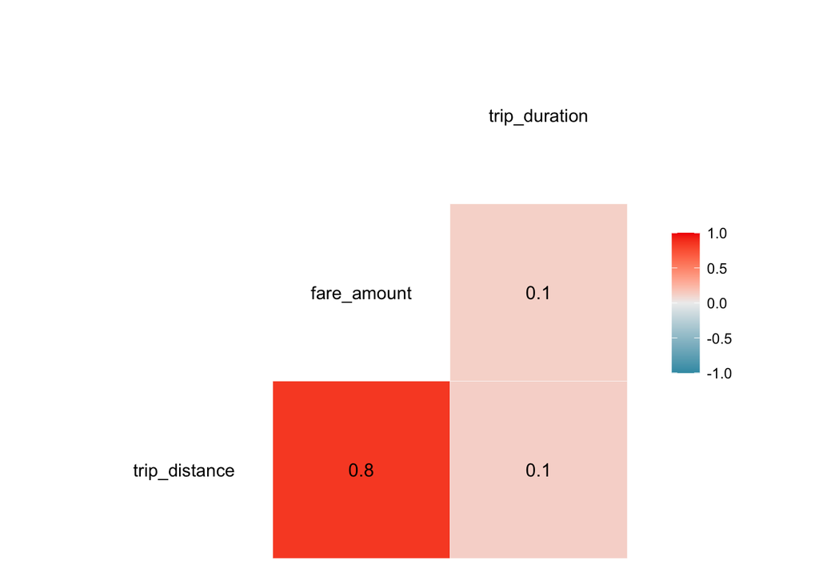

```r
ggcorr(trip, label = T)
```

> I will remove *fare_amount* because it’s highly correlated to *trip_distance*. Why do I choose to remove *fare_amount* instead of *trip_distance*? Because as I know, *fare_amount* is a dependent variable

## **Feature selection**

### Remove unused columns

I’ll remove the datetime columns and *fare_amount*

```r
trip <- trip %>% select(-PU_datetime,
                        -DO_datetime,
                        -fare_amount)

trip %>% head()
```

|  | PULocationID | DOLocationID | trip_distance | trip_duration | is_weekend | hour |
| --- | --- | --- | --- | --- | --- | --- |
| 1 | 74 | 168 | 1.20 | 4.73 | 0 | 0 |
| 2 | 116 | 265 | 13.69 | 35.92 | 0 | 0 |
| 3 | 97 | 33 | 0.95 | 6.03 | 0 | 0 |
| 4 | 74 | 42 | 1.24 | 5.72 | 0 | 0 |
| 5 | 42 | 244 | 1.10 | 7.23 | 0 | 0 |
| 6 | 24 | 239 | 1.90 | 6.83 | 0 | 0 |

### Check target variable summary

By looking at the target summary, I can detect weird records or people may call them anomalies

```r
trip$trip_duration %>% summary()
```

```
##    Min. 1st Qu.  Median    Mean 3rd Qu.    Max.
##    0.00    8.52   14.00   21.86   23.00 1438.77
```

> There are 2 anomalies:
> 1. `trip_duration == 0`. Did they teleport?
> 2. `trip_duration == 1438.77`. Were they dragging the car?

### Handle target anomalies

```r
trip <- trip %>%
  killOutliers(trip_duration) %>%
  filter(trip_duration >= 1)
```

### Check target variable’s summary again

```r
trip$trip_duration %>% summary()
```

```
##    Min. 1st Qu.  Median    Mean 3rd Qu.    Max.
##    1.00    8.33   13.73   15.84   21.30   44.72
```

> Perfecto

### Average Trip Duration

It would be great if I could aggregate to get and use the average trip_duration of each POLocationID to DOLocationID as a feature with this code below:

```r
trip %>%
  group_by(PULocationID, DOLocationID) %>%
  summarise(average_duration = mean(trip_duration))
```

| PULocationID | DOLocationID | average_duration |
| --- | --- | --- |
| 3 | 3 | 8.756250 |
| 3 | 7 | 23.000000 |
| 3 | 18 | 22.580000 |
| 3 | 20 | 12.000000 |
| 3 | 32 | 7.666667 |
| 3 | 41 | 26.000000 |
| 3 | 42 | 29.000000 |
| 3 | 46 | 21.500000 |
| 3 | 47 | 29.370000 |
| 3 | 51 | 9.777778 |

[output cut: 9990 more lines]

> But unfortunately, I don’t have enough data :(

## **Exploratory Data Analysis**

### Distribution of Trip Duration

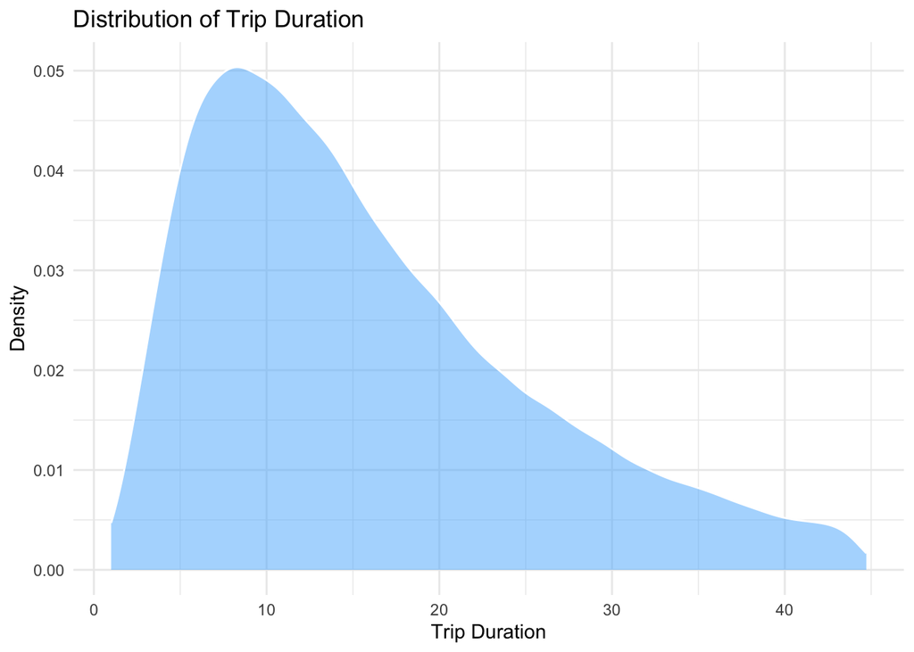

```r
ggplot(trip, aes(x = trip_duration)) +
  geom_density(fill = "#56b4fc", col = "white", alpha = 0.5) +
  labs(x = "Trip Duration",
       y = "Density",
       title = "Distribution of Trip Duration") +
  theme_minimal()
```

### Distribution of Trip Distance

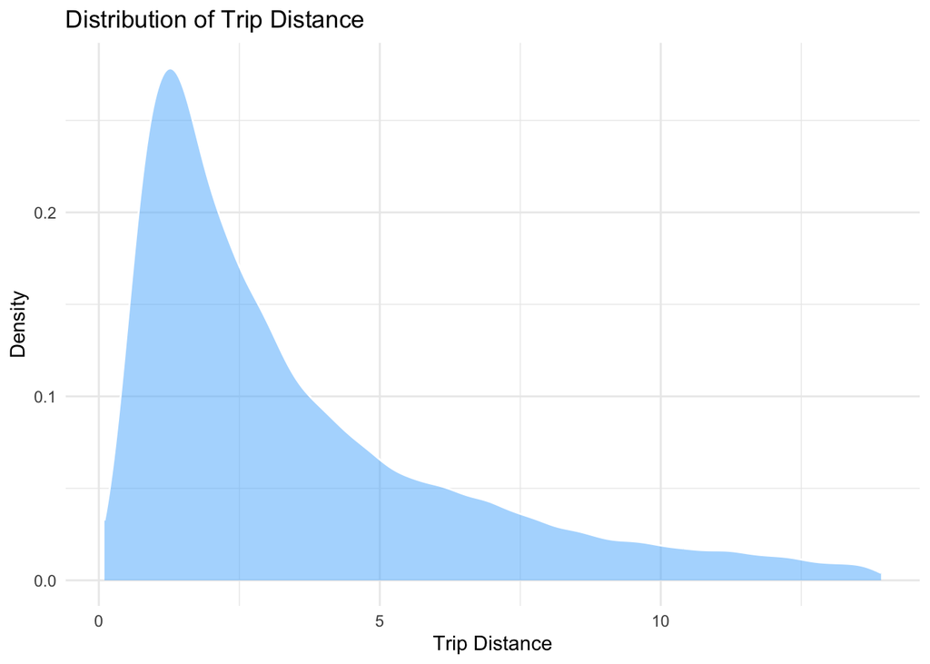

```r
ggplot(trip, aes(x = trip_distance)) +
  geom_density(fill = "#56b4fc", col = "white", alpha = 0.5) +
  labs(x = "Trip Distance",
       y = "Density",
       title = "Distribution of Trip Distance") +
  theme_minimal()
```

### Trip Distance & Duration Relationship per Hour Range

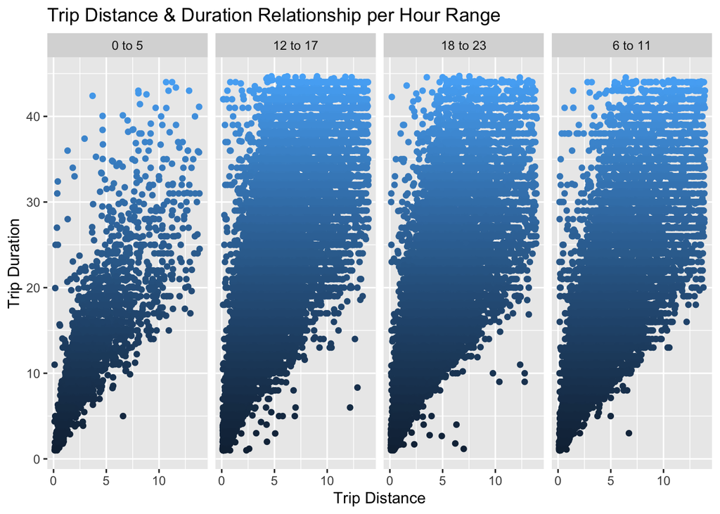

```r
plot_data <- trip %>% mutate(hour_range = getHourRange(as.integer(hour))) # getHourRange() is from personal package my package

ggplot(plot_data, aes(x = trip_distance, y = trip_duration, color = trip_duration)) +
  geom_point() +
  labs(x = "Trip Distance",
       y = "Trip Duration",
       title = "Trip Distance & Duration Relationship per Hour Range",
       color = "Is Weekend") +
  theme_gray() +
  facet_grid(. ~ hour_range) +
  theme(legend.position = "none")
```

> They are mostly the same in terms of the the relationship pattern

### Number of Trips by Hour

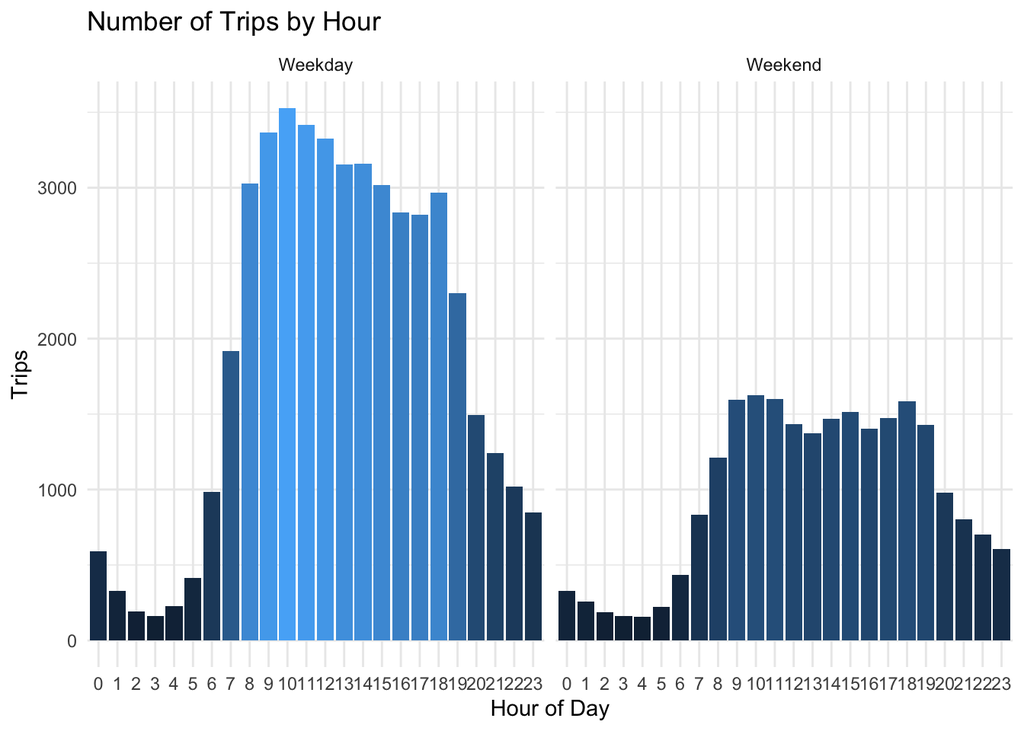

```r
plot_data <- trip %>%
  group_by(hour, is_weekend) %>%
  summarise(count = n()) %>%
  ungroup()

ggplot(plot_data, aes(x = hour, y = count)) +
  geom_bar(stat = "identity", aes(fill = count), show.legend = F) +
  labs(x = "Hour of Day",
       y = "Trips",
       title = "Number of Trips by Hour") +
  facet_grid(. ~ is_weekend,
             labeller = labeller(is_weekend = c("0" = "Weekday", "1" = "Weekend"))) +
  theme_minimal()
```

> Number of trips are high around 8 to 18 o’clock

### Average Trip Duration per Distance by hour

This will give us insight into which hours experience high traffic congestion the most

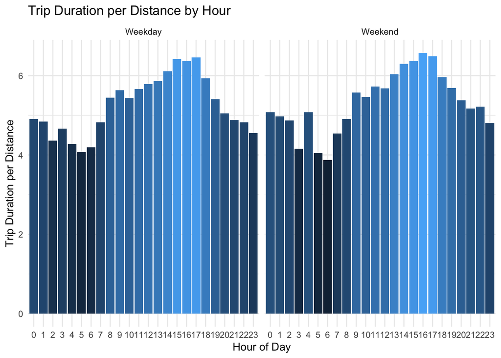

```r
plot_data <- trip %>%
  group_by(hour, is_weekend) %>%
  summarise(ratio = mean(trip_duration/trip_distance)) %>%
  ungroup()

ggplot(plot_data, aes(x = hour, y = ratio)) +
  geom_bar(stat = "identity", aes(fill = ratio), show.legend = F) +
  labs(x = "Hour of Day",
       y = "Trip Duration per Distance",
       title = "Trip Duration per Distance by Hour") +
  facet_grid(. ~ is_weekend,
             labeller = labeller(is_weekend = c("0" = "Weekday", "1" = "Weekend"))) +
  theme_minimal()
```

> Traffic congestion mostly occur between 13 and 18 o’clock

## **Cross Validation**

### Set random seed and training indices

```r
set.seed(1)

indices <- createDataPartition(trip$trip_duration,
                               p = 0.8,
                               list = FALSE)
```

### Train test split

```r
train_data <- trip[indices, ] %>% select(-PULocationID,
                                         -DOLocationID)
test_data <- trip[-indices, ] %>% select(-PULocationID,
                                         -DOLocationID)

X_train <- train_data %>% select(-trip_duration)
y_train <- train_data$trip_duration

X_test <- test_data %>% select(-trip_duration)
y_test <- test_data$trip_duration
```

## **Model Fitting**

### Linear Regression Algorithm

```r
model_lm <- lm(formula = trip_duration ~ .,
               data = train_data)

model_lm %>% summary()
```

```
##
## Call:
## lm(formula = trip_duration ~ ., data = train_data)
##
## Residuals:
##     Min      1Q  Median      3Q     Max
## -34.147  -3.466  -0.827   2.662  37.326
##
## Coefficients:
##                Estimate Std. Error t value Pr(>|t|)
## (Intercept)    3.797590   0.213754  17.766  < 2e-16 ***
## trip_distance  2.636803   0.008239 320.050  < 2e-16 ***
## is_weekend1   -0.014847   0.050868  -0.292  0.77039
## hour1         -0.328531   0.333683  -0.985  0.32485
## hour2         -0.389243   0.388882  -1.001  0.31687
## hour3         -1.181921   0.416058  -2.841  0.00450 **
## hour4         -1.300279   0.385308  -3.375  0.00074 ***
## hour5         -1.599021   0.329178  -4.858 1.19e-06 ***
## hour6         -0.600088   0.269575  -2.226  0.02601 *
## hour7          1.198183   0.243219   4.926 8.40e-07 ***
## hour8          2.230058   0.232150   9.606  < 2e-16 ***
## hour9          2.301029   0.229197  10.040  < 2e-16 ***
## hour10         2.126995   0.228501   9.308  < 2e-16 ***
## hour11         2.809875   0.229031  12.269  < 2e-16 ***
## hour12         3.077923   0.230163  13.373  < 2e-16 ***
## hour13         3.726444   0.231074  16.127  < 2e-16 ***
## hour14         4.274314   0.230670  18.530  < 2e-16 ***
## hour15         4.493975   0.230991  19.455  < 2e-16 ***
## hour16         4.578300   0.231953  19.738  < 2e-16 ***
## hour17         4.325192   0.232275  18.621  < 2e-16 ***
## hour18         3.189397   0.231089  13.802  < 2e-16 ***
## hour19         1.987397   0.234743   8.466  < 2e-16 ***
## hour20         1.446235   0.246563   5.866 4.50e-09 ***
## hour21         1.369564   0.253470   5.403 6.57e-08 ***
## hour22         0.671668   0.260220   2.581  0.00985 **
## hour23         0.557497   0.268400   2.077  0.03780 *
## ---
## Signif. codes:  0 '***' 0.001 '**' 0.01 '*' 0.05 '.' 0.1 ' ' 1
##
## Residual standard error: 5.657 on 55748 degrees of freedom
## Multiple R-squared:  0.6517, Adjusted R-squared:  0.6515
## F-statistic:  4172 on 25 and 55748 DF,  p-value: < 2.2e-16
```

### Linear Regression Model Evaluation

```r
pred_lm <- predict(model_lm, X_test)

getRegressionErrors(pred_lm, y_test) # This function is from my personal package
```

```
##  Target Min   Max   MAE   MAPE    MSE  RMSE
##           1 44.68 4.134 36.954 31.381 5.602
```

> Not so good. But don’t worry! I’ll try another algorithm

### Random Forest Algorithm

```r
model_rf <- randomForest(x = X_train,
                         y = y_train,
                         ntree = 55,
                         mtry = ncol(X_train),
                         importance = T)

model_rf
```

```
##
## Call:
##  randomForest(x = X_train, y = y_train, ntree = 55, mtry = ncol(X_train),      importance = T)
##                Type of random forest: regression
##                      Number of trees: 55
## No. of variables tried at each split: 3
##
##           Mean of squared residuals: 31.62449
##                     % Var explained: 65.56
```

### Random Forest Model Evaluation

```r
pred_rf <- predict(model_rf, X_test)

getRegressionErrors(pred_rf, y_test)
```

```
##  Target Min   Max   MAE   MAPE    MSE  RMSE
##           1 44.68 3.949 29.498 31.481 5.611
```

> It’s way better than my linear regression model in terms of MAPE. But, I’ll try using Feed-Forward Neural Network Architecture

## **Deep Learning**

### One Hot Encoding

```r
factor_columns <- c("PULocationID", "DOLocationID", "is_weekend", "hour")
trip_encoded <- oneHotEncode(trip, factor_columns) %>% as.matrix() # oneHotEncode() is from my personal package

X_train <- trip_encoded[indices, -which(colnames(trip_encoded) == 'trip_duration')]
y_train <- trip_encoded[indices, "trip_duration"]

X_test <- trip_encoded[-indices, -which(colnames(trip_encoded) == 'trip_duration')]
y_test <- trip_encoded[-indices, "trip_duration"]
```

### Feed-Forward Neural Network

```r
model_fnn <- keras_model_sequential(name = "ETA-Predictor_NYC-Taxi_1.0.0") %>%
  layer_dense(units = 256,
              activation = "relu",
              input_shape = ncol(X_train),
              name = "hidden_1") %>%
  layer_dense(units = 128,
              activation = "relu",
              name = "hidden_2") %>%
  layer_dense(units = 64,
              activation = "relu",
              name = "hidden_3") %>%
  layer_dense(units = 1,
              activation = "linear",
              name = "output")

model_fnn %>% compile(
  loss = "mean_squared_error",
  optimizer = optimizer_adam(learning_rate = 0.01),
  metrics = "mean_absolute_percentage_error" # I'm gonna use MAPE as the metric because the trip_duration is never gonna be zero
)

history <- model_fnn %>% fit(
  X_train, y_train,
  epochs = 18,
  batch_size = 8192,
  validation_data = list(X_test, y_test),
  verbose = 1
)

model_fnn
```

```
## Model: "ETA-Predictor_NYC-Taxi_1.0.0"
## ________________________________________________________________________________
##  Layer (type)                       Output Shape                    Param #
## ================================================================================
##  hidden_1 (Dense)                   (None, 256)                     137216
##  hidden_2 (Dense)                   (None, 128)                     32896
##  hidden_3 (Dense)                   (None, 64)                      8256
##  output (Dense)                     (None, 1)                       65
## ================================================================================
## Total params: 178,433
## Trainable params: 178,433
## Non-trainable params: 0
## ________________________________________________________________________________
```

### Feed-Forward Neural Network Model Evaluation

```r
pred_fnn <- predict(model_fnn, X_test) %>% as.vector()

getRegressionErrors(pred_fnn, y_test)
```

```
##  Target Min   Max   MAE   MAPE    MSE  RMSE
##           1 44.68 3.213 25.254 20.603 4.539
```

> Alhamdulillah! It’s way better than my random forest model in terms of all metrics! But, I’ll try and see how KNN algorithm performs

## **Further Model Fitting**

### K-Nearest Neighbour Regressor Algorithm

```r
pred_knn_train <- knn.reg(train = X_train,
                          test = X_train,
                          y = y_train,
                          k = 5)$pred

pred_knn_test <- knn.reg(train = X_train,
                         test = X_test,
                         y = y_train,
                         k = 5)$pred
```

### K-Nearest Neighbour Evaluation

```r
getRegressionErrors(pred_knn_test, y_test)
```

```
##  Target Min   Max   MAE   MAPE   MSE RMSE
##           1 44.68 3.461 26.676 24.21 4.92
```

> It’s cool, but my FNN model is better. What if I combine them?

## **Model Combining**

I will try combining KNN and FNN model, I will add the predicted value from KNN as a feature and see how the FNN performs

### Add KNN prediction as a feature

```r
X_train <- cbind(X_train, pred_knn = pred_knn_train)
X_test <- cbind(X_test, pred_knn = pred_knn_test)
```

### Feed-Forward Neural Network with KNN prediction

```r
model_fnn_knn <- keras_model_sequential(name = "ETA-Predictor_NYC-Taxi_1.0.1") %>%
  layer_dense(units = 256,
              activation = "relu",
              input_shape = ncol(X_train),
              name = "hidden_1") %>%
  layer_dense(units = 128,
              activation = "relu",
              name = "hidden_2") %>%
  layer_dense(units = 64,
              activation = "relu",
              name = "hidden_3") %>%
  layer_dense(units = 1,
              activation = "linear",
              name = "output")

model_fnn_knn %>% compile(
  loss = "mean_squared_error",
  optimizer = optimizer_adam(learning_rate = 0.01),
  metrics = "mean_absolute_percentage_error"
)

history <- model_fnn_knn %>% fit(
  X_train, y_train,
  epochs = 30,
  batch_size = 8192,
  validation_data = list(X_test, y_test),
  verbose = 1
)

model_fnn_knn
```

```
## Model: "ETA-Predictor_NYC-Taxi_1.0.1"
## ________________________________________________________________________________
##  Layer (type)                       Output Shape                    Param #
## ================================================================================
##  hidden_1 (Dense)                   (None, 256)                     137472
##  hidden_2 (Dense)                   (None, 128)                     32896
##  hidden_3 (Dense)                   (None, 64)                      8256
##  output (Dense)                     (None, 1)                       65
## ================================================================================
## Total params: 178,689
## Trainable params: 178,689
## Non-trainable params: 0
## ________________________________________________________________________________
```

#### New Feed-Forward Neural Network Model Evaluation

```r
pred_fnn_knn <- predict(model_fnn_knn, X_test) %>% as.vector()

getRegressionErrors(pred_fnn_knn, y_test)
```

```
##  Target Min   Max   MAE   MAPE    MSE RMSE
##           1 44.68 3.296 24.798 22.282 4.72
```

> Not better than my original FNN model.

## **Model Selection**

So, the model that wins the model selection is:

```r
model_fnn
```

```
## Model: "ETA-Predictor_NYC-Taxi_1.0.0"
## ________________________________________________________________________________
##  Layer (type)                       Output Shape                    Param #
## ================================================================================
##  hidden_1 (Dense)                   (None, 256)                     137216
##  hidden_2 (Dense)                   (None, 128)                     32896
##  hidden_3 (Dense)                   (None, 64)                      8256
##  output (Dense)                     (None, 1)                       65
## ================================================================================
## Total params: 178,433
## Trainable params: 178,433
## Non-trainable params: 0
## ________________________________________________________________________________
```

> Congratulations to our model **model_fnn**

## **Regression Assumptions**

### 1. Linearity

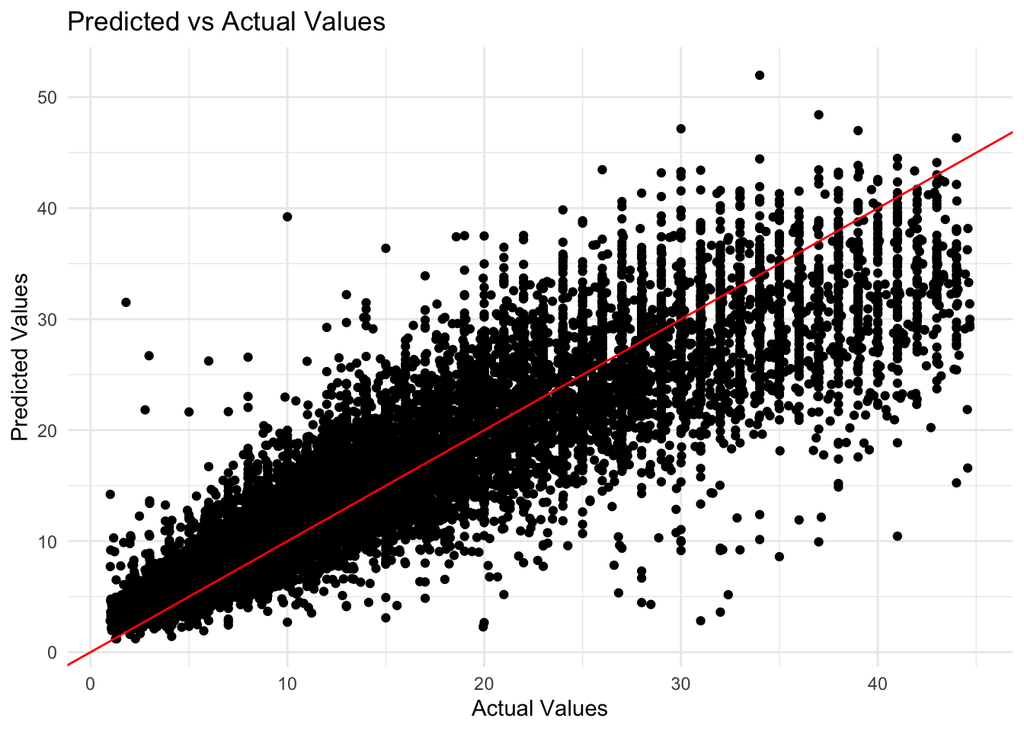

```r
residuals_fnn <- y_test - pred_fnn

ggplot(data = data.frame(y_test = y_test, pred_fnn = pred_fnn), aes(x = y_test, y = pred_fnn)) +
  geom_point() +
  geom_abline(intercept = 0, slope = 1, color = "red") +
  labs(title = "Predicted vs Actual Values",
       x = "Actual Values",
       y = "Predicted Values") +
  theme_minimal()
```

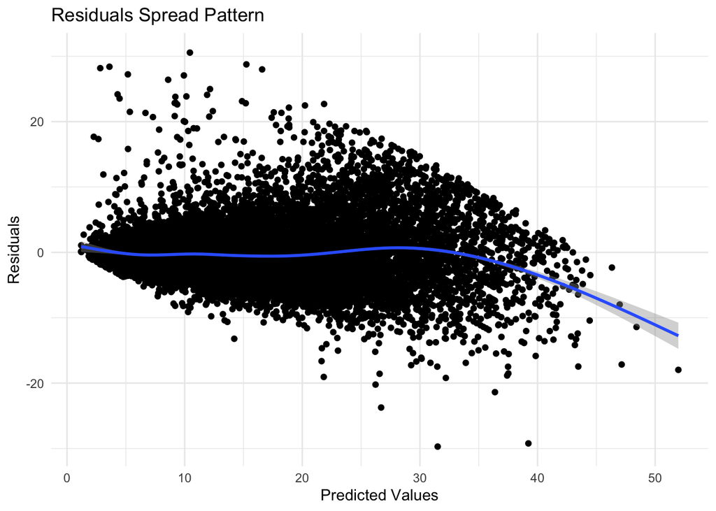

```r
ggplot(data.frame(pred_fnn, residuals_fnn),
       aes(x = pred_fnn, y = residuals_fnn)) +
  geom_point() +
  geom_smooth() +
  labs(title = "Residuals Spread Pattern",
       x = "Predicted Values",
       y = "Residuals") +
  theme_minimal()
```

### 2. Normality of Residuals

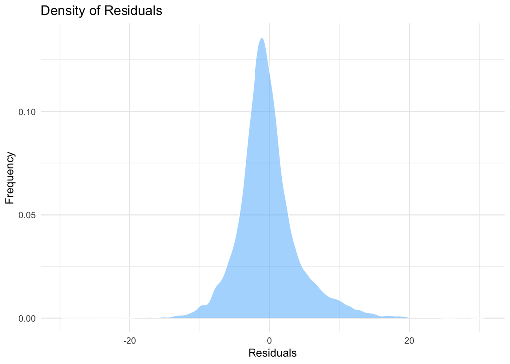

```r
ggplot(data = data.frame(residuals_fnn), aes(x = residuals_fnn)) +
  geom_density(fill = "#56b4fc", col = "white", alpha = 0.5) +
  labs(title = "Density of Residuals",
       x = "Residuals",
       y = "Frequency") +
  theme_minimal()
```

> Cool. Why? Cause the residuals are mostly around zero

### 3. Homoscedasticity of Residuals

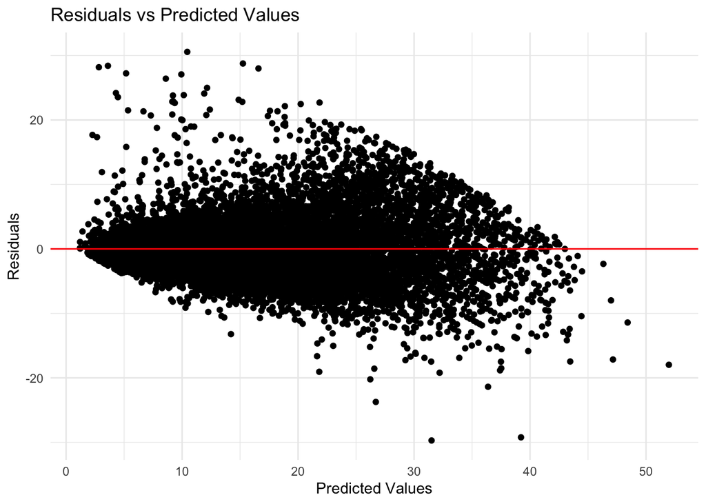

```r
ggplot(data = data.frame(pred_fnn, residuals_fnn), aes(x = pred_fnn, y = residuals_fnn)) +
  geom_point() +
  geom_hline(yintercept = 0, color = "red") +
  labs(title = "Residuals vs Predicted Values",
       x = "Predicted Values",
       y = "Residuals") +
  theme_minimal()
```

### 4. No Multicollinearity

Because my neural network model uses encoded features, I can’t directly do multicollinearity check. So I’m gonna use my linear model just to check the multicollinearity of the features

```r
vif(model_lm)
```

```
##                   GVIF Df GVIF^(1/(2*Df))
## trip_distance 1.016746  1        1.008338
## is_weekend    1.006300  1        1.003145
## hour          1.023017 23        1.000495
```

> Cool. Why? Cause there’s no feature with vif >= 10